# Лабораторная работа №10

Операционные системы

Верниковская Е. А., НПИбд-01-23

Российский университет дружбы народов, Москва, Россия

10 апреля 2024

# Вводная часть

## Цель работы

Ознакомиться с операционной системой Linux. Получить практические навыки работы с редактором vi, установленным по умолчанию практически во всех дистрибутивах.

## Задание

1. Ознакомиться с теоретическим материалом.
2. Ознакомиться с редактором vi.
3. Выполнить упражнения, используя команды vi.

# Выполнение лабораторной работы

## Задание 1. Создание нового файла с использованием vi

Создаём каталог с именем ~/work/os/lab10 (рис. 1)

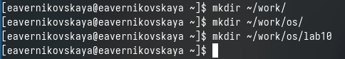

Создание каталога

## Задание 1. Создание нового файла с использованием vi

Переходим в только что сохданный каталог (рис. 2)

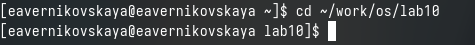

Переход в созданный каталог

## Задание 1. Создание нового файла с использованием vi

Далее вызываем vi и создаём файл hello.sh командой *vi hello.sh* (рис. 3), (рис. 4)

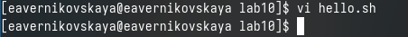

Вызов vi (1)

## Задание 1. Создание нового файла с использованием vi

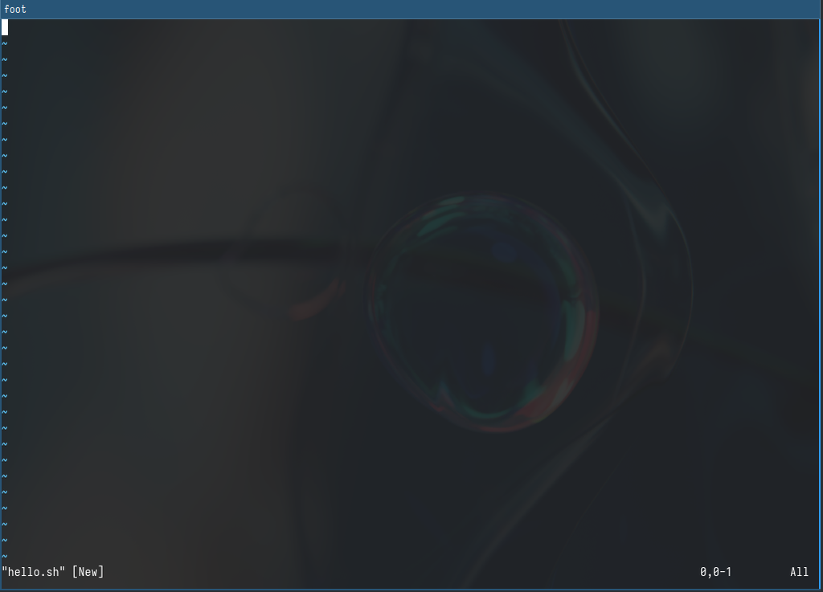

Открытый редактор vi

## Задание 1. Создание нового файла с использованием vi

Вводим нужный текст: (рис. 6)

```
#!/bin/bash
HELL=Hello
function hello {
    LOCAL HELLO=World
    echo $HELLO
}
echo $HELLO
hello
```

## Задание 1. Создание нового файла с использованием vi

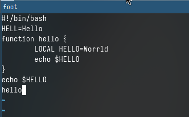

Введённый текст

## Задание 1. Создание нового файла с использованием vi

Далее делаем файл исполняемым введя *chmod +x hello.sh* (рис. 10)

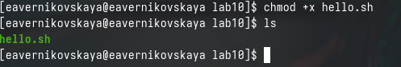

Добавление прав на исполнение

## Задание 2. Редактирование существующего файла

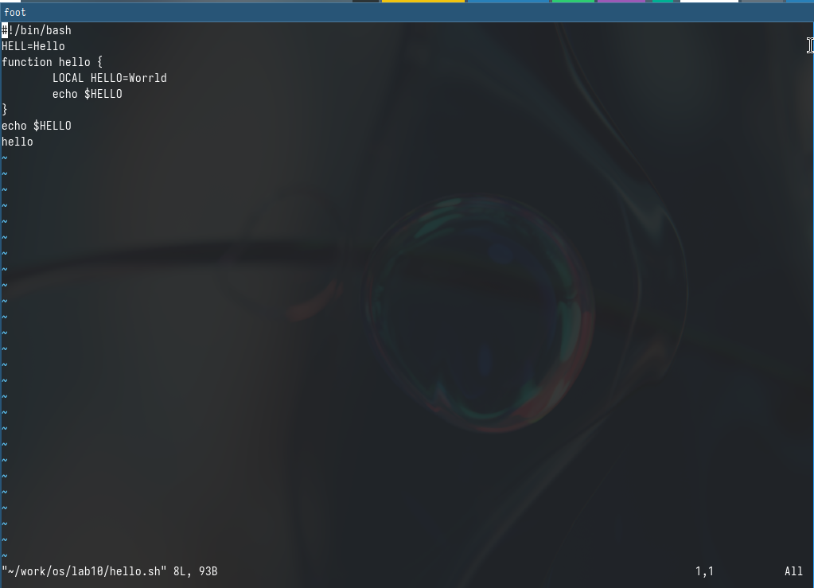

Открытый файл

## Задание 2. Редактирование существующего файла

Устанавливаем курсор в конец слова HELL второй строки (рис. 13)

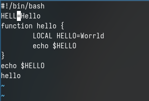

Курсор в конце слова HELL

## Задание 2. Редактирование существующего файла

Далее переходим в режим вставки нажав *i* и заменяем на HELLO. После нажимаем на *esc* для возврата в командный режим (рис. 14)

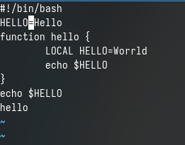

Замена HELL на HELLO

## Задание 2. Редактирование существующего файла

После устанавливаем курсор на четвёртую строку и стираем слово LOCAL (рис. 15)

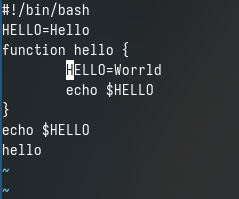

Без слова LOCAL

## Задание 2. Редактирование существующего файла

Переходим в режим вставки и набираем слово local. После переходим опять в командный режим (рис. 16)

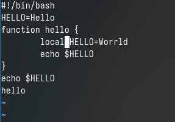

Замена на local

## Задание 2. Редактирование существующего файла

Далее устанавливаем курсор на последней строке файла и вставляем туда следующий текст: echo $HELLO (рис. 17)

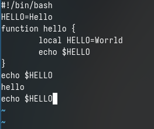

Вставка echo $HELLO

## Задание 2. Редактирование существующего файла

Переходим снова в командный режим. Далее удаляем последнюю строку (рис. 18)

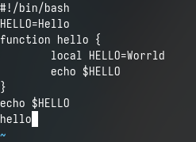

Удаление последней строки

## Задание 2. Редактирование существующего файла

После вводим команду отмены изменений нажав на *u* (рис. 19)

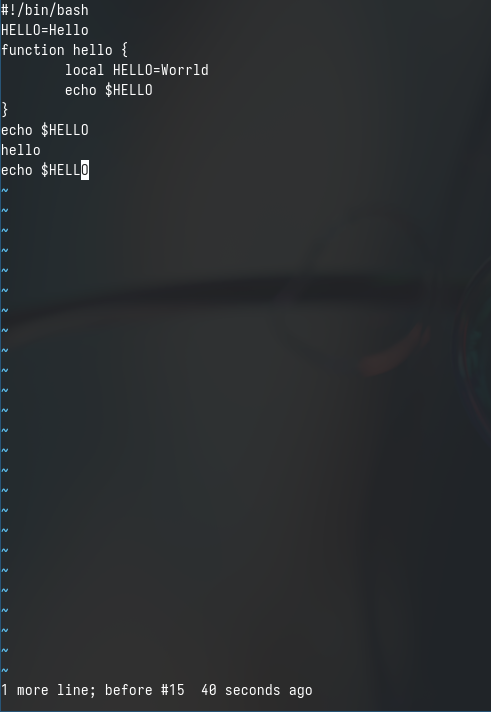

Отмена последнего действия

## Задание 2. Редактирование существующего файла

# Подведение итогов

## Выводы

В ходе выполнения лабораторной работы мы ознакомились с операционной системой Linux а также получили практические навыки работы с редактором vi, установленным по умолчанию практически во всех дистрибутивах.

## Список литературы

Не пользовалась сайтами.